# South West

## Mid Somerset Consortium for Teacher Training

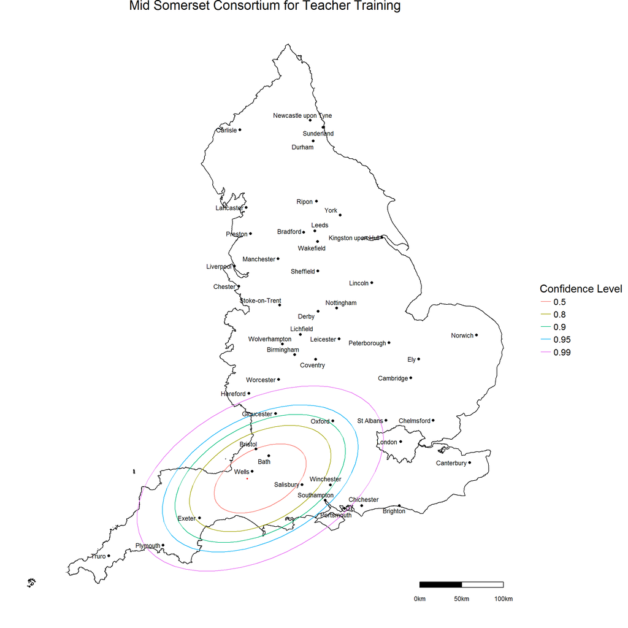

For Mid Somerset Consortium for Teacher Training 41 % of leavers travel 25km or less to their first job as NQT and 6 % travel more than 100km. The percentage of students staying within 25km of Mid Somerset Consortium for Teacher Training is higher than the regional average.

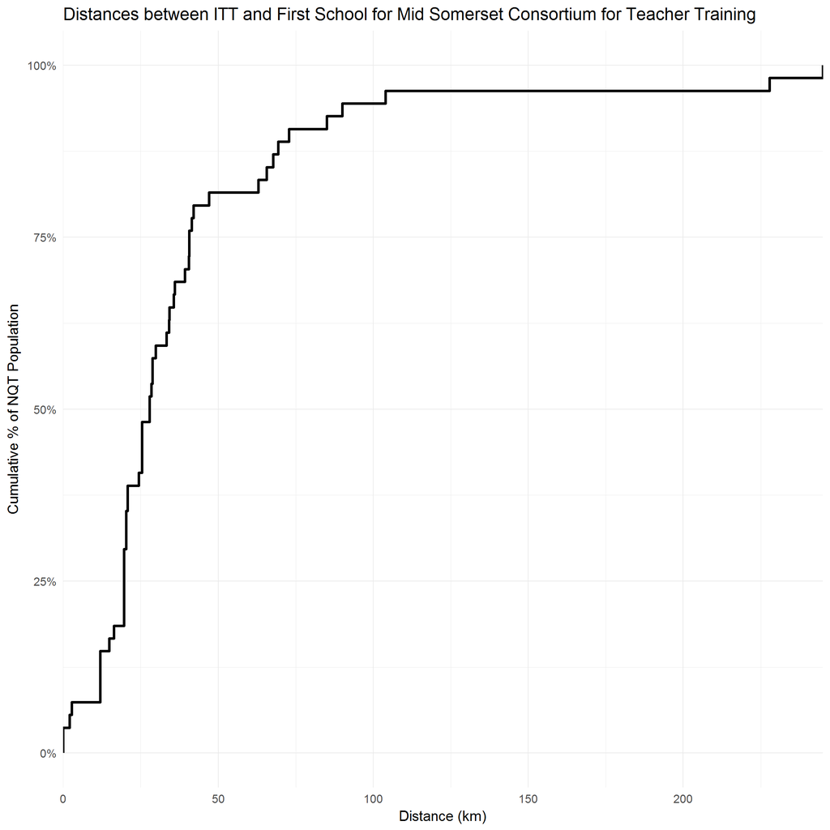

## All providers in South West

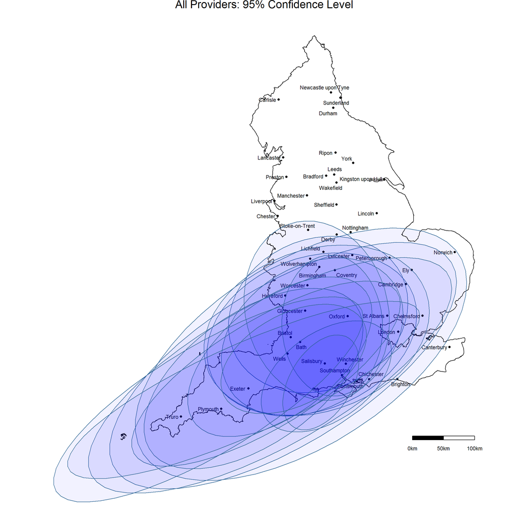

For All providers in South West 34 % of leavers travel 25km or less to their first job as NQT and 32 % travel more than 100km.

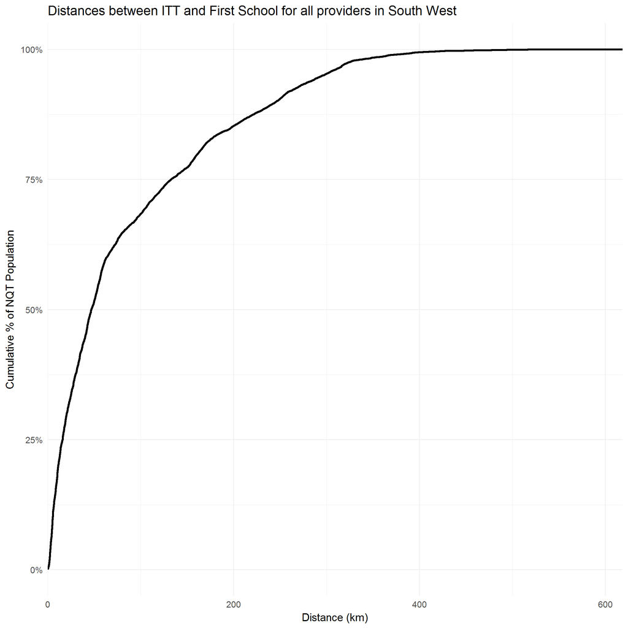

[^1]: Due to an assumption being made about the data being normally distributed the confidence ellipses may not be a complete true reflection of the shape of the area where leavers travel post training. However, the size of the ellipses and their direction can provide meaningful comparison of distances travelled from each provider.
[^2]: The Ellipse’s two axes are in the directions of the eigenvectors of the covariance matrix of the bivariate normal distribution and the middle of the ellipse is the mean of the distribution. The half-length of the axes for each confidence level are the square root of the eigenvalues of the covariance matrix multiplied by the square root of the critical value of a Chi-Squared distribution with 2 degrees of freedom for alpha being 0.05 (1-0.95). We use the R package ggplot2 and the function stat_ellipse to calculate and draw the normal ellipse curves.